# MScA, Linear and Non-Linear Models (31010) Week 7: Workshop 1 Gamma Regression

© Yuri Balasanov, iLykei 2016

```r
suppressWarnings(library(faraway))
suppressWarnings(library(MASS))
suppressWarnings(library(lmtest))
```

# 1 Wafers example

Example in Chapter 7 shows data from experiment with manufactured semiconductors.  
There are four possible factors affecting the resistivity of a wafer.  
A full factorial experiment design is applied with 4 factors at 2 levels each.

```r
data(wafer)
wafer
```

```
##    x1 x2 x3 x4 resist
## 1   -  -  -  -  193.4
## 2   +  -  -  -  247.6
## 3   -  +  -  -  168.2
## 4   +  +  -  -  205.0
## 5   -  -  +  -  303.4
## 6   +  -  +  -  339.9
## 7   -  +  +  -  226.3
## 8   +  +  +  -  208.3
## 9   -  -  -  +  220.0
## 10  +  -  -  +  256.4
## 11  -  +  -  +  165.7
## 12  +  +  -  +  203.5
## 13  -  -  +  +  285.0
## 14  +  -  +  +  268.0
## 15  -  +  +  +  169.1
## 16  +  +  +  +  208.5
```

```r
summary(wafer)
```

```
##  x1    x2    x3    x4        resist
##  -:8   -:8   -:8   -:8   Min.   :165.7
##  +:8   +:8   +:8   +:8   1st Qu.:201.0
##                          Median :214.2
##                          Mean   :229.3
##                          3rd Qu.:259.3
##                          Max.   :339.9
```

Check the distribution of resistivity.

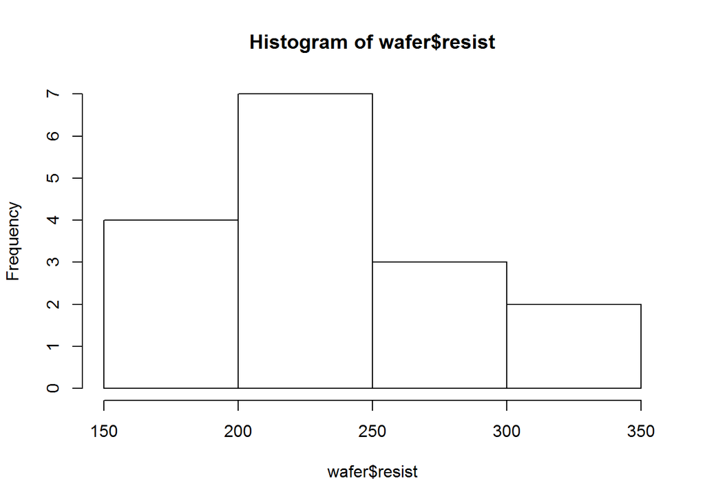

```r
hist(wafer$resist)
```

```r
(fitGamma<-fitdistr(wafer$resist,"gamma"))
```

```
##       shape         rate
##   23.09377758    0.10072802
##  ( 8.09441183) ( 0.03568919)
```

```r
ks.test(wafer$resist,"pgamma",shape=fitGamma$estimate[1],rate=fitGamma$estimate[2])
```

```
##
##  One-sample Kolmogorov-Smirnov test
##
## data:  wafer$resist
## D = 0.14774, p-value = 0.8273
## alternative hypothesis: two-sided
```

The null hypothesis that the sample is consistent with gamma distribution cannot be rejected.

Check normal and lognormal distributions for the resistivity data.

```r
fit<-fitdistr(wafer$resist,"normal")
ks.test(wafer$resist,"pnorm",fit$estimate[1],fit$estimate[2])
```

```
##
##  One-sample Kolmogorov-Smirnov test
##
## data:  wafer$resist
## D = 0.16438, p-value = 0.721
## alternative hypothesis: two-sided
```

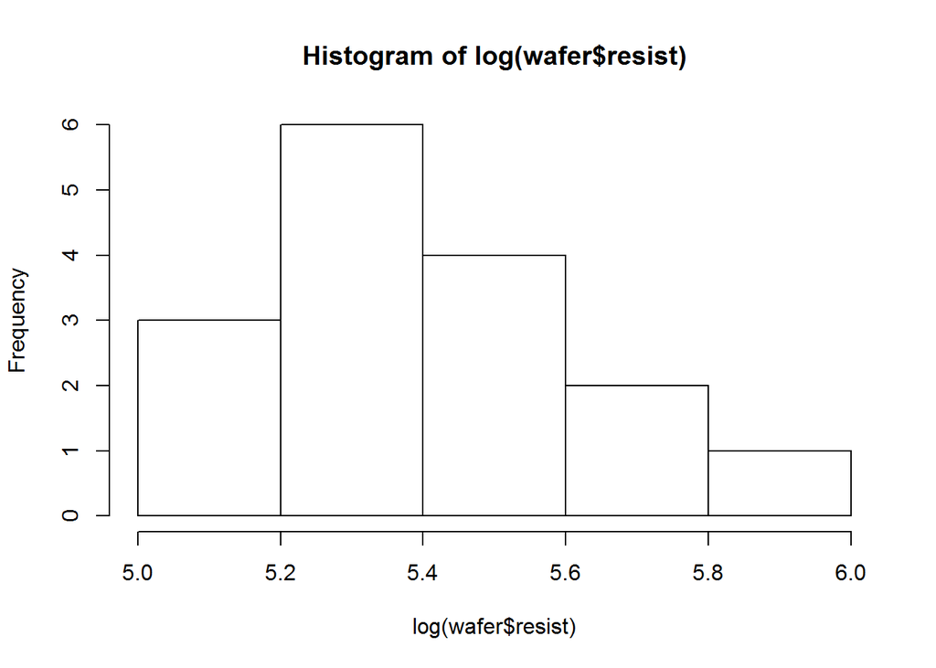

```r
hist(log(wafer$resist))
```

```r
lnfit<-fitdistr(log(wafer$resist),"normal")
ks.test(log(wafer$resist),"pnorm",lnfit$estimate[1],lnfit$estimate[2])
```

```
##
##  One-sample Kolmogorov-Smirnov test
##
## data:  log(wafer$resist)
## D = 0.13807, p-value = 0.8806
## alternative hypothesis: two-sided
```

Both normal and lognormal distributions can describe the data too. The sample is too small to decide.

Following the book, fit linear model with log transformation and gamma model without transformation.

Fit a lognormal model.

```r
llmdl <- lm(log(resist) ~ .^2, wafer)
rlmdl <- step(llmdl)
```

```
## Start:  AIC=-76.51
## log(resist) ~ (x1 + x2 + x3 + x4)^2
##
##         Df Sum of Sq      RSS     AIC
## - x1:x4  1  0.000060 0.033967 -78.479
## - x1:x2  1  0.000377 0.034284 -78.331
## - x2:x4  1  0.001942 0.035850 -77.616
## <none>               0.033907 -76.507
## - x1:x3  1  0.024402 0.058309 -69.833
## - x2:x3  1  0.031771 0.065678 -67.929
## - x3:x4  1  0.033499 0.067407 -67.514
##
## Step:  AIC=-78.48
## log(resist) ~ x1 + x2 + x3 + x4 + x1:x2 + x1:x3 + x2:x3 + x2:x4 +
##     x3:x4
##
##         Df Sum of Sq      RSS     AIC
## - x1:x2  1  0.000377 0.034344 -80.303
## - x2:x4  1  0.001942 0.035910 -79.589
## <none>               0.033967 -78.479
## - x1:x3  1  0.024402 0.058369 -71.817
## - x2:x3  1  0.031771 0.065738 -69.915
## - x3:x4  1  0.033499 0.067466 -69.499
##
## Step:  AIC=-80.3
## log(resist) ~ x1 + x2 + x3 + x4 + x1:x3 + x2:x3 + x2:x4 + x3:x4
##
##         Df Sum of Sq      RSS     AIC
## - x2:x4  1  0.001942 0.036286 -81.422
## <none>               0.034344 -80.303
## - x1:x3  1  0.024402 0.058746 -73.714
## - x2:x3  1  0.031771 0.066115 -71.823
## - x3:x4  1  0.033499 0.067843 -71.410
##
## Step:  AIC=-81.42
## log(resist) ~ x1 + x2 + x3 + x4 + x1:x3 + x2:x3 + x3:x4
##
##         Df Sum of Sq      RSS     AIC
## <none>               0.036286 -81.422
## - x1:x3  1  0.024402 0.060688 -75.193
## - x2:x3  1  0.031771 0.068057 -73.360
## - x3:x4  1  0.033499 0.069786 -72.959
```

```r
summary(rlmdl)
```

```
##
## Call:
## lm(formula = log(resist) ~ x1 + x2 + x3 + x4 + x1:x3 + x2:x3 +
##     x3:x4, data = wafer)
##
## Residuals:
##       Min        1Q    Median        3Q       Max
## -0.081164 -0.036518 -0.000397  0.038557  0.083618
##
## Coefficients:
##             Estimate Std. Error t value Pr(>|t|)
## (Intercept)  5.31111    0.04762 111.525 4.67e-14 ***
## x1+          0.20088    0.04762   4.218  0.00292 **
## x2+         -0.21073    0.04762  -4.425  0.00221 **
## x3+          0.43718    0.06735   6.491  0.00019 ***
## x4+          0.03537    0.04762   0.743  0.47892
## x1+:x3+     -0.15621    0.06735  -2.319  0.04896 *
## x2+:x3+     -0.17824    0.06735  -2.647  0.02941 *
## x3+:x4+     -0.18303    0.06735  -2.718  0.02635 *
## ---
## Signif. codes:  0 '***' 0.001 '**' 0.01 '*' 0.05 '.' 0.1 ' ' 1
##
## Residual standard error: 0.06735 on 8 degrees of freedom
## Multiple R-squared:  0.9471, Adjusted R-squared:  0.9008
## F-statistic: 20.46 on 7 and 8 DF,  p-value: 0.000165
```

The best model selected by `step()` has 3 interactions terms, all with factor 3. Factor 4 does not seem to be significant.

Fit a gamma model. Use log link in order to compare the models.

```r
gmdl <- glm(resist ~ .^2, family=Gamma(link=log), wafer)
rgmdl <- step(gmdl)
```

```
## Start:  AIC=144.11
## resist ~ (x1 + x2 + x3 + x4)^2
##
##         Df Deviance    AIC
## - x1:x4  1 0.033944 142.12
## - x1:x2  1 0.034281 142.17
## - x2:x4  1 0.035808 142.40
## <none>     0.033882 144.11
## - x1:x3  1 0.057723 145.64
## - x2:x3  1 0.064983 146.71
## - x3:x4  1 0.067121 147.03
##
## Step:  AIC=142.14
## resist ~ x1 + x2 + x3 + x4 + x1:x2 + x1:x3 + x2:x3 + x2:x4 +
##     x3:x4
##
##         Df Deviance    AIC
## - x1:x2  1 0.034343 140.21
## - x2:x4  1 0.035869 140.48
## <none>     0.033944 142.14
## - x1:x3  1 0.057785 144.36
## - x2:x3  1 0.064998 145.64
## - x3:x4  1 0.067183 146.03
##
## Step:  AIC=140.33
## resist ~ x1 + x2 + x3 + x4 + x1:x3 + x2:x3 + x2:x4 + x3:x4
##
##         Df Deviance    AIC
## - x2:x4  1 0.036266 138.72
## <none>     0.034343 140.33
## - x1:x3  1 0.058187 143.19
## - x2:x3  1 0.065399 144.66
## - x3:x4  1 0.067434 145.08
##
## Step:  AIC=139.2
## resist ~ x1 + x2 + x3 + x4 + x1:x3 + x2:x3 + x3:x4
##
##         Df Deviance    AIC
## <none>     0.036266 139.20
## - x1:x3  1 0.060433 142.54
## - x2:x3  1 0.067314 144.06
## - x3:x4  1 0.069345 144.51
```

```r
summary(rgmdl)
```

```
##
## Call:
## glm(formula = resist ~ x1 + x2 + x3 + x4 + x1:x3 + x2:x3 + x3:x4,
##     family = Gamma(link = log), data = wafer)
##
## Deviance Residuals:
##       Min         1Q     Median         3Q        Max
## -0.083185  -0.036793  -0.000648   0.038199   0.081390
##
## Coefficients:
##             Estimate Std. Error t value Pr(>|t|)
## (Intercept)  5.31195    0.04757 111.677 4.62e-14 ***
## x1+          0.20029    0.04757   4.211  0.00295 **
## x2+         -0.21101    0.04757  -4.436  0.00218 **
## x3+          0.43674    0.06727   6.493  0.00019 ***
## x4+          0.03537    0.04757   0.744  0.47836
## x1+:x3+     -0.15549    0.06727  -2.312  0.04957 *
## x2+:x3+     -0.17626    0.06727  -2.620  0.03064 *
## x3+:x4+     -0.18195    0.06727  -2.705  0.02687 *
## ---
## Signif. codes:  0 '***' 0.001 '**' 0.01 '*' 0.05 '.' 0.1 ' ' 1
##
## (Dispersion parameter for Gamma family taken to be 0.004524942)
##
##     Null deviance: 0.697837  on 15  degrees of freedom
## Residual deviance: 0.036266  on  8  degrees of freedom
## AIC: 139.2
##
## Number of Fisher Scoring iterations: 4
```

Observe that all coefficients returned by both models are very similar.  
Square root of dispersion parameter is the same as `sigma` returned by lognormal model.

```r
sqrt(summary(rgmdl)$dispersion)
```

```
## [1] 0.06726769
```

```r
summary(rlmdl)$sigma
```

```
## [1] 0.06734844
```

**Conclusion:** both models return practically equivalent results because the estimated gamma distribution is very close to normal.

# 2 Insurance claims example

Another example shows payments of car insurance claims for different regions in Sweden.  
The predicting variables represent:

- Mileage driven (`Kilometres’) - categorical variable; for example, level 1 means less than 1,000 kilometers per year
- Bonus for no previous claims; equals number of years since last claim, plus 1
- The make of the car; factor of 8 main car makes, level 9 is for “Other”
- Numbers of insured (policy-years) within each group
- Payment - total value of payments in Skr
- Payment per claim `perd`

```r
data(motorins)
head(motorins)
```

```
##   Kilometres Zone Bonus Make Insured Claims Payment     perd
## 1          1    1     1    1  455.13    108  392491 3634.176
## 2          1    1     1    2   69.17     19   46221 2432.684
## 3          1    1     1    3   72.88     13   15694 1207.231
## 4          1    1     1    4 1292.39    124  422201 3404.847
## 5          1    1     1    5  191.01     40  119373 2984.325
## 6          1    1     1    6  477.66     57  170913 2998.474
```

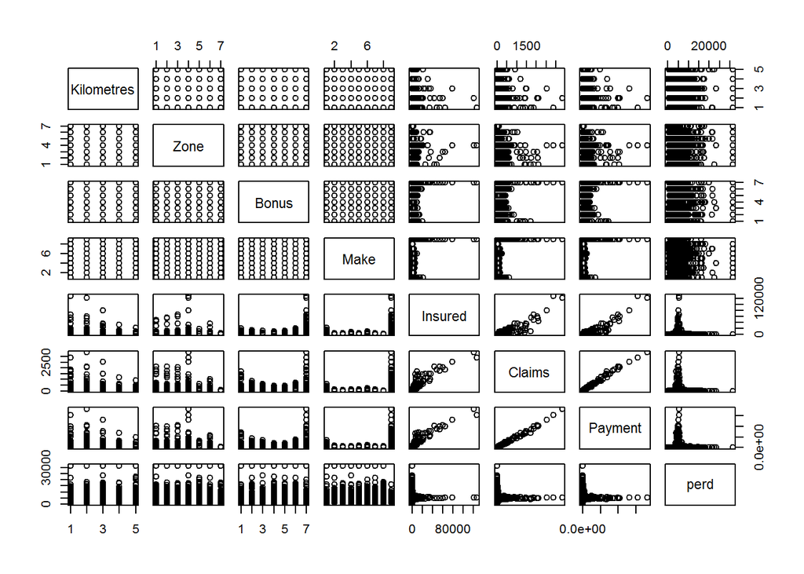

```r
plot(motorins)
```

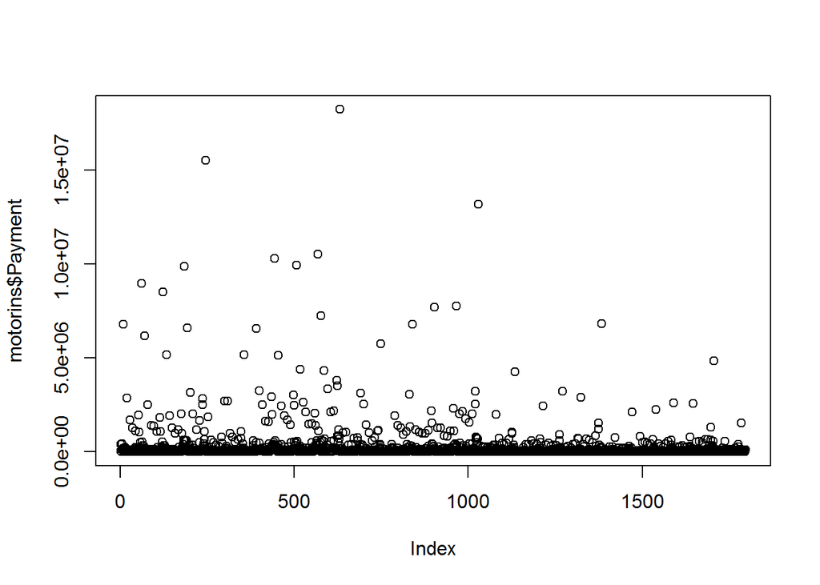

```r
plot(motorins$Payment)
```

Check distribution of variable `Payment`.

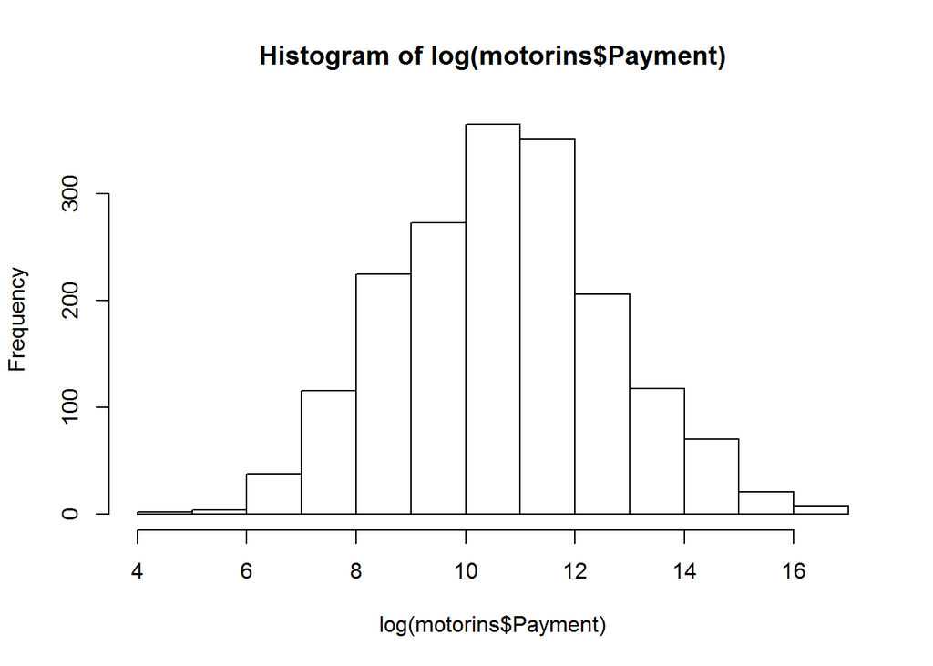

```r
hist(log(motorins$Payment))
```

```r
fit<-fitdistr(log(motorins$Payment),"normal")
ks.test(log(motorins$Payment),"pnorm",fit$estimate[1],fit$estimate[2])
```

```
##
##  One-sample Kolmogorov-Smirnov test
##
## data:  log(motorins$Payment)
## D = 0.032238, p-value = 0.04774
## alternative hypothesis: two-sided
```

Here Gaussian distribution is not consistent with the data with level5% or higher.

Select only Zone 1.  
Fit gamma regression model.  
The payment variable is expected to be proportional to the number of insured.  
In order to avoid estimation of coefficient that is very close to 1 fix this coefficient at 1 and do not estimate it.

```r
motori <- motorins[motorins$Zone == 1,]
gl <- glm(Payment ~ offset(log(Insured))+as.numeric(Kilometres)+Make+Bonus , family=Gamma(link=log), motori)
summary(gl)
```

```
##
## Call:
## glm(formula = Payment ~ offset(log(Insured)) + as.numeric(Kilometres) +
##     Make + Bonus, family = Gamma(link = log), data = motori)
##
## Deviance Residuals:
##      Min        1Q    Median        3Q       Max
## -2.03727  -0.63467  -0.09602   0.26508   2.70324
##
## Coefficients:
##                        Estimate Std. Error t value Pr(>|t|)
## (Intercept)             6.52731    0.17774  36.723  < 2e-16 ***
## as.numeric(Kilometres)  0.12007    0.03115   3.855 0.000143 ***
## Make2                   0.40704    0.17824   2.284 0.023128 *
## Make3                   0.15535    0.17955   0.865 0.387666
## Make4                  -0.34394    0.19150  -1.796 0.073546 .
## Make5                   0.14467    0.18097   0.799 0.424726
## Make6                  -0.34557    0.17824  -1.939 0.053515 .
## Make7                   0.06136    0.18244   0.336 0.736893
## Make8                   0.75038    0.18726   4.007 7.85e-05 ***
## Make9                   0.03197    0.17824   0.179 0.857783
## Bonus                  -0.20069    0.02150  -9.334  < 2e-16 ***
## ---
## Signif. codes:  0 '***' 0.001 '**' 0.01 '*' 0.05 '.' 0.1 ' ' 1
##
## (Dispersion parameter for Gamma family taken to be 0.5559565)
##
##     Null deviance: 238.97  on 294  degrees of freedom
## Residual deviance: 155.06  on 284  degrees of freedom
## AIC: 7167.5
##
## Number of Fisher Scoring iterations: 6
```

Function `offset()` is used to avoid estimation of the slope of the corresponding variable. Instead, this slope is set to 1.  
The corresponding lognormal function is:

```r
llg <- glm(log(Payment) ~ offset(log(Insured))+as.numeric(Kilometres)+Make+Bonus,family=gaussian ,  motori)
summary(llg)
```

```
##
## Call:
## glm(formula = log(Payment) ~ offset(log(Insured)) + as.numeric(Kilometres) +
##     Make + Bonus, family = gaussian, data = motori)
##
## Deviance Residuals:
##      Min        1Q    Median        3Q       Max
## -2.28524  -0.41757   0.02732   0.46135   2.47377
##
## Coefficients:
##                         Estimate Std. Error t value Pr(>|t|)
## (Intercept)             6.514035   0.186339  34.958  < 2e-16 ***
## as.numeric(Kilometres)  0.057132   0.032654   1.750  0.08126 .
## Make2                   0.363869   0.186857   1.947  0.05248 .
## Make3                   0.006916   0.188235   0.037  0.97072
## Make4                  -0.547855   0.200755  -2.729  0.00675 **
## Make5                  -0.021785   0.189720  -0.115  0.90866
## Make6                  -0.458814   0.186857  -2.455  0.01467 *
## Make7                  -0.321179   0.191264  -1.679  0.09420 .
## Make8                   0.209578   0.196310   1.068  0.28661
## Make9                   0.125446   0.186857   0.671  0.50254
## Bonus                  -0.178061   0.022540  -7.900 6.17e-14 ***
## ---
## Signif. codes:  0 '***' 0.001 '**' 0.01 '*' 0.05 '.' 0.1 ' ' 1
##
## (Dispersion parameter for gaussian family taken to be 0.611019)
##
##     Null deviance: 238.56  on 294  degrees of freedom
## Residual deviance: 173.53  on 284  degrees of freedom
## AIC: 704.64
##
## Number of Fisher Scoring iterations: 2
```

There are differences between the models in this example.  
The mileage predictor is very significant in the gamma model and not significant with 5% level in lognormal model.  
Some coefficients are different. For example `Make8`.

```r
cbind(gl=exp(gl$coefficients),llg=exp(llg$coefficients))
```

```
##                                 gl         llg
## (Intercept)            683.5565030 674.5426077
## as.numeric(Kilometres)   1.1275768   1.0587958
## Make2                    1.5023650   1.4388862
## Make3                    1.1680637   1.0069399
## Make4                    0.7089709   0.5781886
## Make5                    1.1556553   0.9784502
## Make6                    0.7078169   0.6320327
## Make7                    1.0632768   0.7252932
## Make8                    2.1178151   1.2331576
## Make9                    1.0324853   1.1336536
## Bonus                    0.8181619   0.8368916
```

The fit of the two models is not easy to compare.  
**AIC would need a complete form of log-likelihood functions of both distributions.**  
But constant terms that do not depend on the parameters are usually omitted.  
That is why `AIC()` does not help here: the difference between them is too big.

```r
c(AIC(gl),AIC(llg))
```

```
## [1] 7167.5419  704.6384
```

**However:** Null deviances of both models are similar, but the residual deviance is better for `gl`.  
We consider `gl` a better fit.  
**Use caution when make conclusions like this. Further analysis of residuals and interpretation of the model is needed.**

To compare shapes of the two fitted distributions plot the probability densities.  
Shape parameters of the distributions are equal to $\frac{1}{Dispersion}$ for gamma model and $\sqrt{Dispersion}$ for the lognormal model.

```r
(shape.llg<-summary(llg)$dispersion)
```

```
## [1] 0.611019
```

```r
(shape.gl<-summary(gl)$dispersion)
```

```
## [1] 0.5559565
```

both densities are normalized to have unit mean.

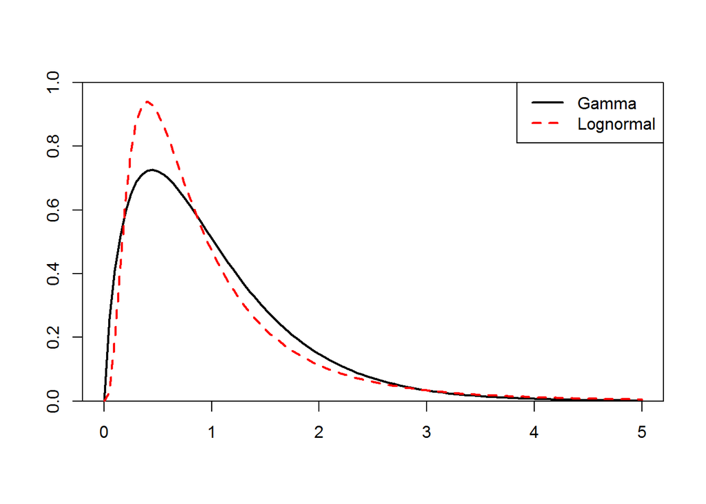

```r
x <- seq(0,5,by=0.05)
plot(x,dgamma(x,1/shape.gl,scale=shape.gl),
     type="l",ylab="",xlab="",yaxs="i",ylim=c(0,1),lwd=2)
lines(x,dlnorm(x,meanlog=-0.30551,sdlog=sqrt(shape.llg)),
      type="l",ylab="",xlab="",yaxs="i",ylim=c(0,1),col="red",lty=2,lwd=2)
legend("topright",legend=c("Gamma","Lognormal"),col=c("black","red"),lty=c(1,2),lwd=2)
```

The number `meanlog` is selected to make mean value of lognormal distribution equal to 1.  
Since $E[X]=exp(\mu+\frac{\sigma ^2}{2})$, where $\mu =-0.30551$ and $\sigma ^2=$ `shape.llg`, obtain:

```r
exp(-0.30551+shape.llg/2)
```

```
## [1] 0.9999995
```

The shape of the lognormal model is more extreme: it shows more small claim payments and fewer, but larger claims on the tail.  
In other words, it has higher kurtosis.

Make predictions using both models for values of predictors given in `x0` below.

```r
(x0 <- data.frame(Make="1",Kilometres=1,Bonus=1,Insured=100))
```

```
##   Make Kilometres Bonus Insured
## 1    1          1     1     100
```

Calculate predictions:

```r
(pr.gl<-predict(gl,new=x0,se=T,type="response"))
```

```
## $fit
##        1
## 63060.85
##
## $se.fit
##        1
## 9711.378
##
## $residual.scale
## [1] 0.7456249
```

```r
(pr.llg<-predict(llg,new=x0,se=T,type="response"))
```

```
## $fit
##        1
## 10.99828
##
## $se.fit
## [1] 0.1614463
##
## $residual.scale
## [1] 0.781677
```

The corresponding values for claims in the original scale are:

```r
c(gl=pr.gl$fit,llg=exp(pr.llg$fit))
```

```
##     gl.1    llg.1
## 63060.85 59771.04
```

# 3 Mean-variance analysis by simulation

Simulate linear model data.

```r
set.seed(8271)
b0<-1
b1<-3
X<-rnorm(100,300,100)
summary(X)
```

```
##    Min. 1st Qu.  Median    Mean 3rd Qu.    Max.
##   77.76  238.00  299.80  306.60  373.80  583.90
```

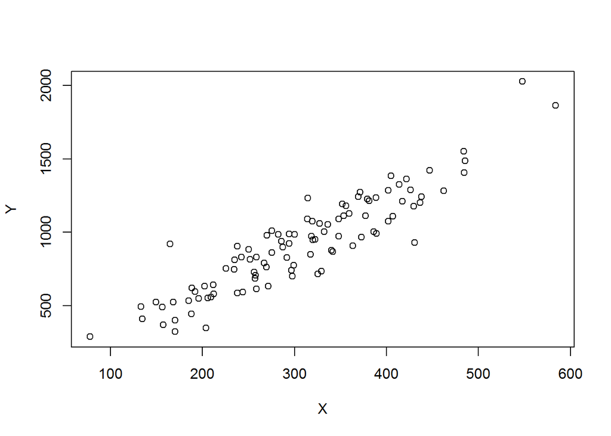

```r
Eps1<-rnorm(100,0,120)
Y<-b0+b1*X+Eps1
plot(X,Y)
```

Fit linear model, check homoskedasticity of residuals.

```r
suppressWarnings(library(lmtest))
```

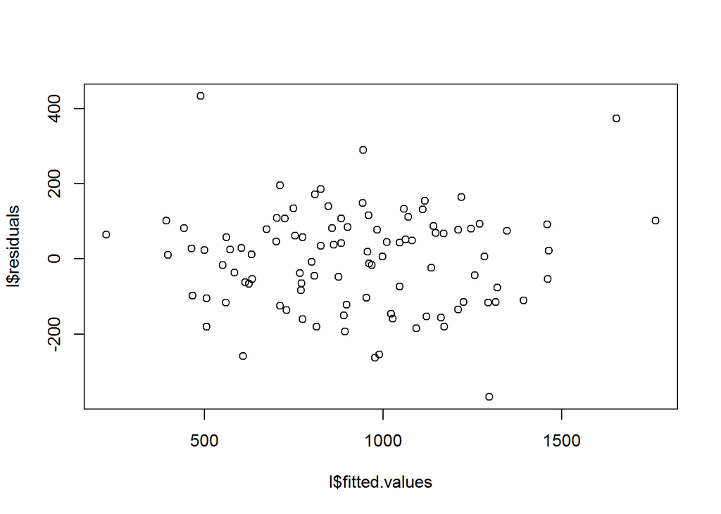

```r
l<-lm(Y~X)
plot(l$fitted.values,l$residuals)
```

```r
idx<-(l$fitted.values<median(l$fitted.values))
bptest(Y~X)
```

```
##
##  studentized Breusch-Pagan test
##
## data:  Y ~ X
## BP = 0.89897, df = 1, p-value = 0.3431
```

```r
fligner.test(l$residuals,idx)
```

```
##
##  Fligner-Killeen test of homogeneity of variances
##
## data:  l$residuals and idx
## Fligner-Killeen:med chi-squared = 0.81907, df = 1, p-value =
## 0.3655
```

Breusch-Pagan test does not reject the null hypothesis of homoskedasticity with any reasonable level. Flinger-Killeen test also shows that $H_0$: homoskedasticity cannot be rejected.

Now simulate residuals that have linear dependence on the predictor.

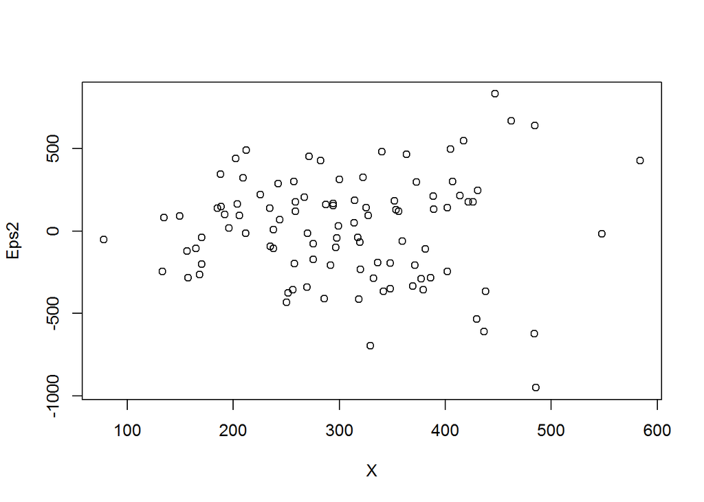

```r
set.seed(8272)
Eps2<-rnorm(100,0,X)
plot(X,Eps2)
```

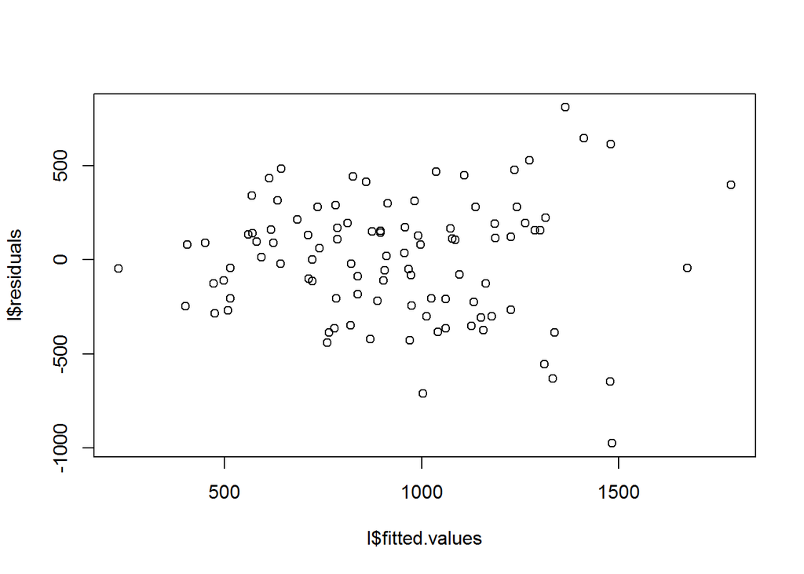

```r
Y<-b0+b1*X+Eps2
l<-lm(Y~X)
idx<-(l$fitted.values<median(l$fitted.values))
plot(l$fitted.values,l$residuals)
```

```r
bptest(Y~X)
```

```
##
##  studentized Breusch-Pagan test
##
## data:  Y ~ X
## BP = 18.701, df = 1, p-value = 1.529e-05
```

```r
fligner.test(l$residuals,idx)
```

```
##
##  Fligner-Killeen test of homogeneity of variances
##
## data:  l$residuals and idx
## Fligner-Killeen:med chi-squared = 9.2205, df = 1, p-value =
## 0.002393
```

The hypothesis of homoskedasticity is rejected by both tests.

Apply square root transformation to the output data.

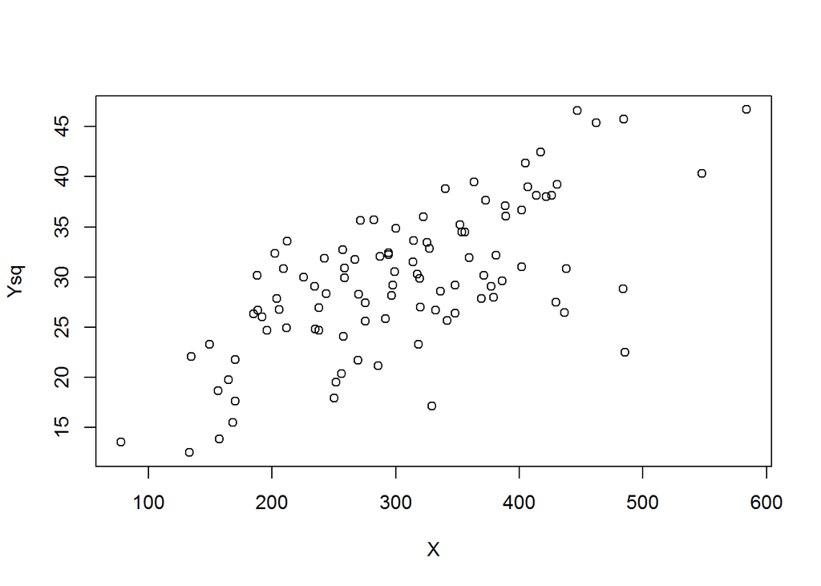

```r
Ysq<-sqrt(Y)
plot(X,Ysq)
```

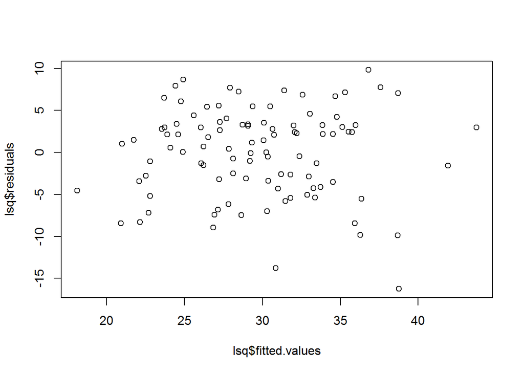

```r
lsq<-lm(Ysq~X)
idx<-(lsq$fitted.values<median(lsq$fitted.values))
plot(lsq$fitted.values,lsq$residuals)
```

```r
bptest(Ysq~X)
```

```
##
##  studentized Breusch-Pagan test
##
## data:  Ysq ~ X
## BP = 3.876, df = 1, p-value = 0.04898
```

```r
fligner.test(lsq$residuals,idx)
```

```
##
##  Fligner-Killeen test of homogeneity of variances
##
## data:  lsq$residuals and idx
## Fligner-Killeen:med chi-squared = 0.98856, df = 1, p-value =
## 0.3201
```

Fligner test does not reject homoskedasticity, BP test will not reject the same hypothesis with levels 0.04898 or lower.

Instead of square root transformation we can use Poisson regression: for Poisson distribution $E[Y]=V[Y]$.  
The only problem is that output has to be positive integer.

```r
Y<-round(Y)
head(Y)
```

```
## [1] 1802 1445  852 1039  389  714
```

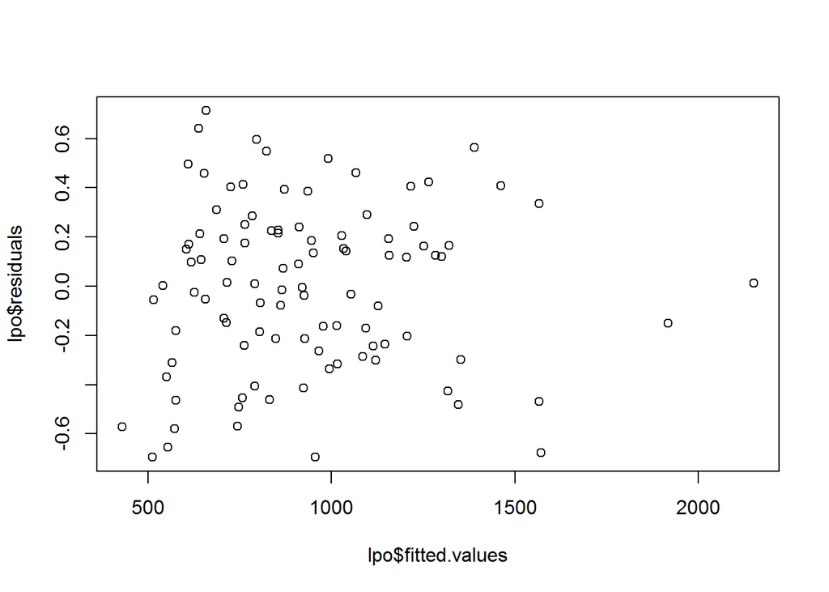

```r
lpo<-glm(Y~X,family=poisson(link=log))
idx<-(lpo$fitted.values<median(lpo$fitted.values))
plot(lpo$fitted.values,lpo$residuals)
```

```r
fligner.test(lpo$residuals,idx)
```

```
##
##  Fligner-Killeen test of homogeneity of variances
##
## data:  lpo$residuals and idx
## Fligner-Killeen:med chi-squared = 0.44932, df = 1, p-value =
## 0.5027
```

# 4 Sales data example

Data sample `cpd` in package `faraway` contains projected ($x_i$) and actual ($y_i$) sales of a range of products.  
Consider model $y_i= \beta x_i$, where $\beta$ represents relative bias in the projected sales.

Plot the data.

```r
data(cpd)
head(cpd)
```

```
##   projected actual
## 1      5959   5673
## 2      3534   3659
## 3      2641   2565
## 4      1965   2182
## 5      1738   1839
## 6      1182   1236
```

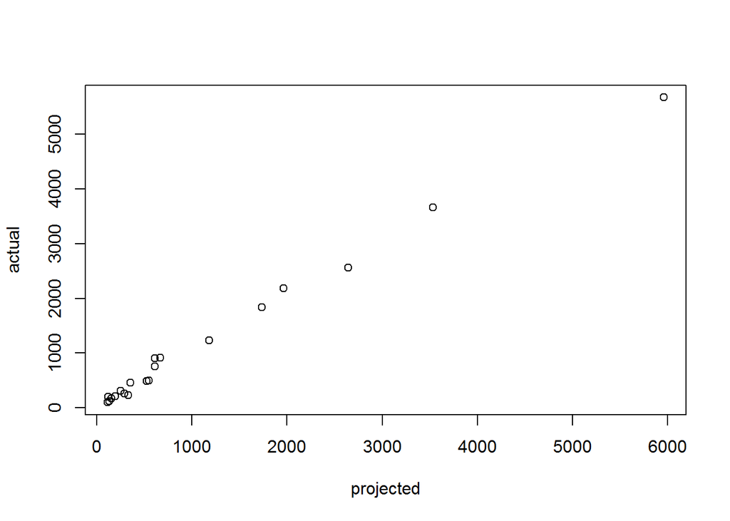

```r
with(cpd,plot(projected,actual))
```

Plot empirical copula to see type of dependency.  
Estimate correlation coefficient.

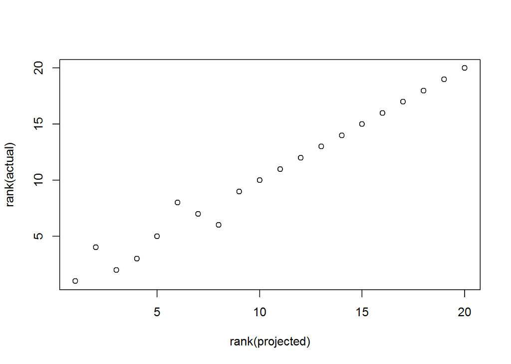

```r
with(cpd,plot(rank(projected),rank(actual)))
```

```r
with(cpd,cor(projected,actual))
```

```
## [1] 0.9962583
```

We see strong comonotonic dependence, possibly explained by correlation.

Fit linear model without intercept.

```r
lmod<-lm(actual~projected-1,cpd)
summary(lmod)
```

```
##
## Call:
## lm(formula = actual ~ projected - 1, data = cpd)
##
## Residuals:
##     Min      1Q  Median      3Q     Max
## -250.39  -32.66   39.83  120.61  292.66
##
## Coefficients:
##           Estimate Std. Error t value Pr(>|t|)
## projected  0.99402    0.01718   57.87   <2e-16 ***
## ---
## Signif. codes:  0 '***' 0.001 '**' 0.01 '*' 0.05 '.' 0.1 ' ' 1
##
## Residual standard error: 139 on 19 degrees of freedom
## Multiple R-squared:  0.9944, Adjusted R-squared:  0.9941
## F-statistic:  3349 on 1 and 19 DF,  p-value: < 2.2e-16
```

Plot the data with the regression line.

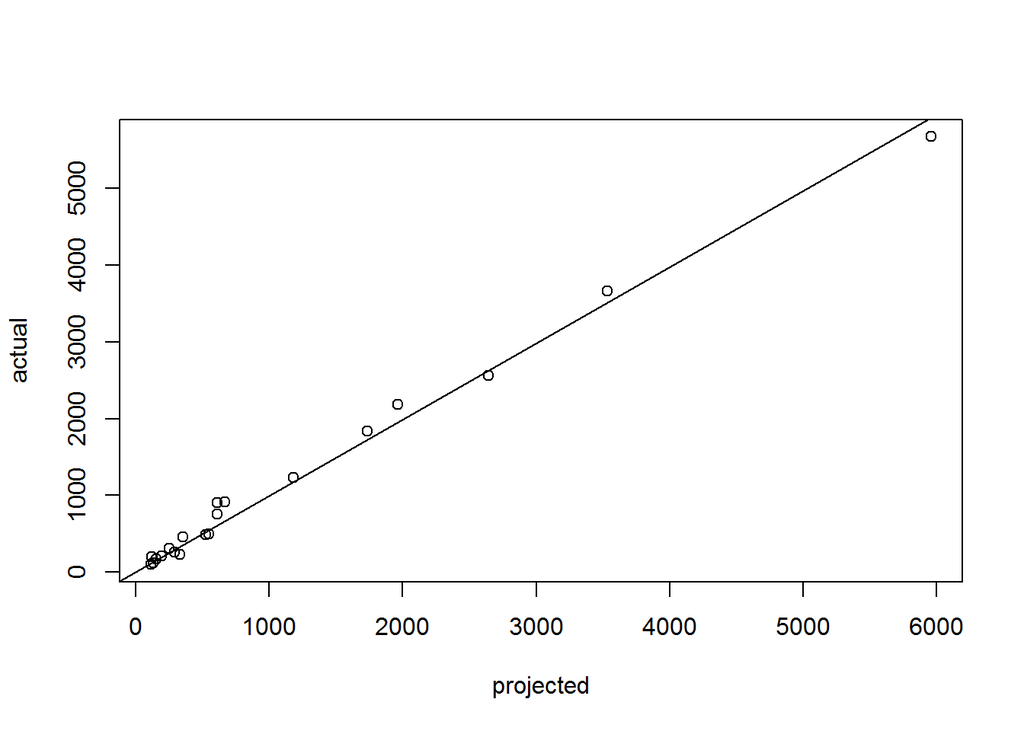

```r
plot(actual~projected,cpd)
abline(lmod)
```

The fit is close to perfect.  
Check the residuals.

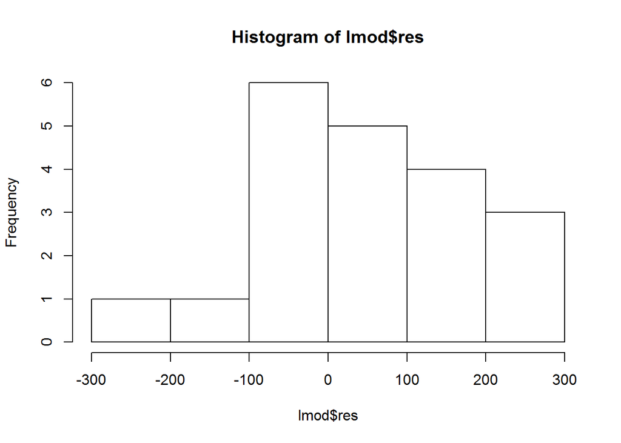

```r
hist(lmod$res)
```

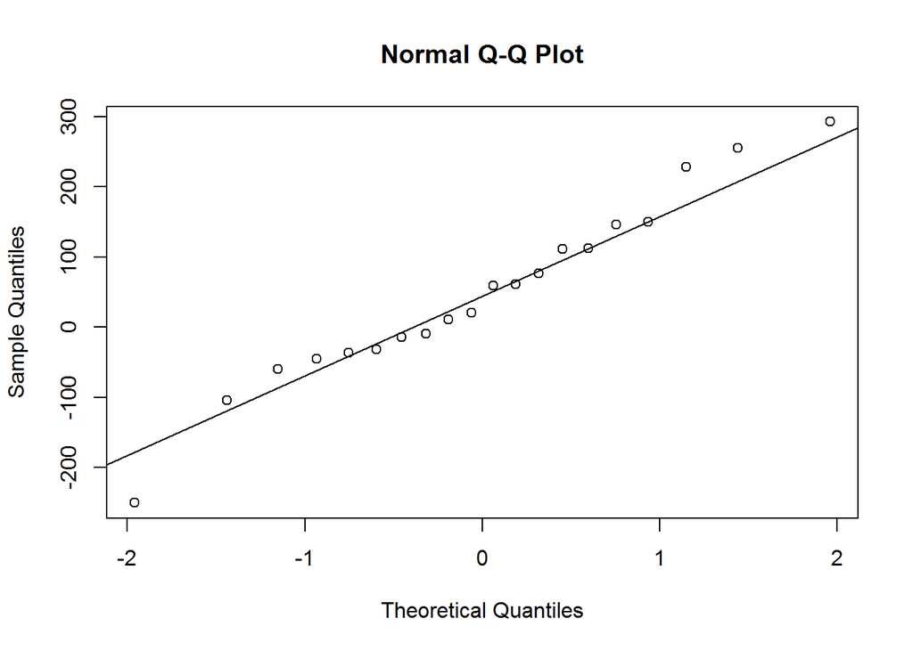

```r
qqnorm(lmod$res)
qqline(lmod$res)
```

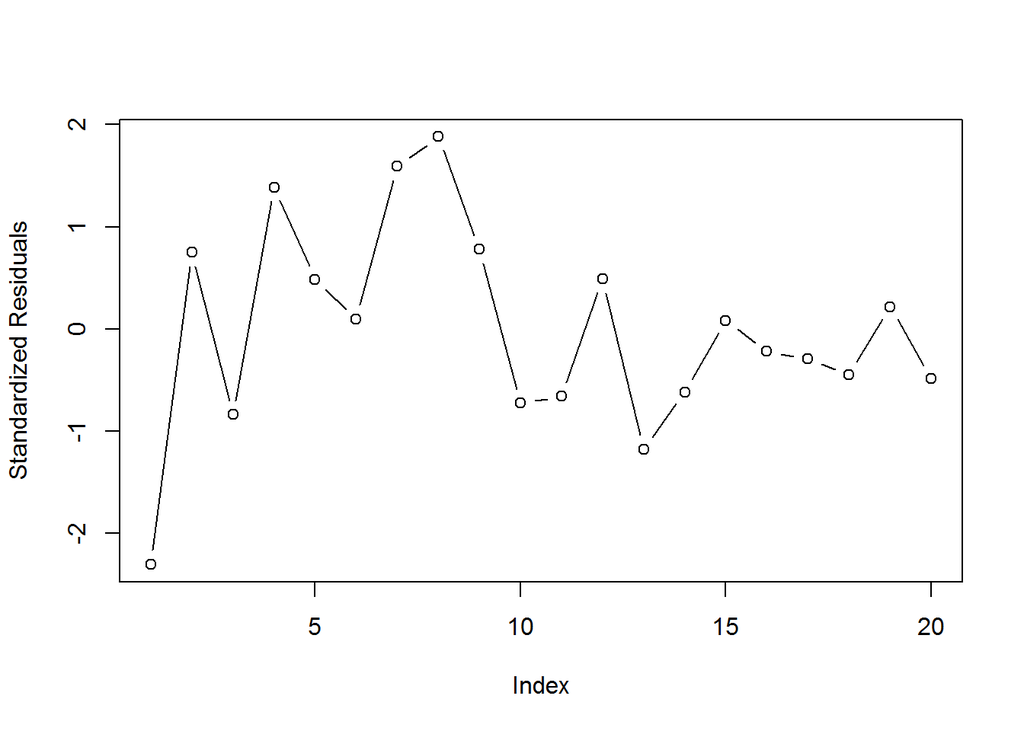

```r
plot((lmod$res-mean(lmod$res))/sd(lmod$res),type="b",ylab="Standardized Residuals")
```

The shape of the distribution is not normal, residuals do not seem to be homoskedastic.

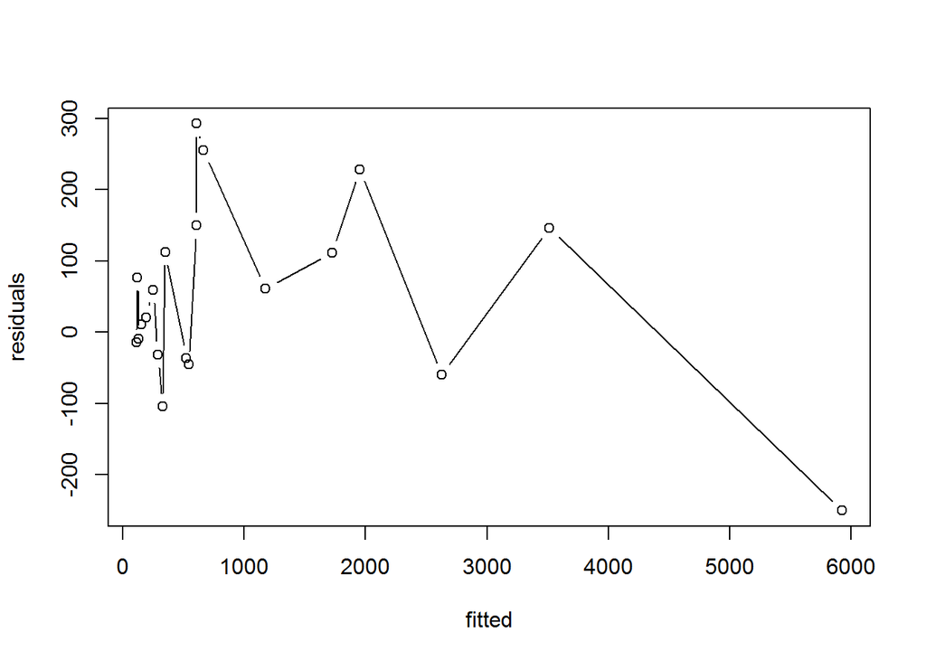

```r
plot(lmod$fitted, lmod$res, xlab="fitted",type="b",   ylab="residuals")
```

```r
idx<-(lmod$fitted.values<median(lmod$fitted.values))
bptest(cpd$actual~cpd$projected)
```

```
##
##  studentized Breusch-Pagan test
##
## data:  cpd$actual ~ cpd$projected
## BP = 2.1425, df = 1, p-value = 0.1433
```

```r
fligner.test(lmod$residuals,idx)
```

```
##
##  Fligner-Killeen test of homogeneity of variances
##
## data:  lmod$residuals and idx
## Fligner-Killeen:med chi-squared = 4.1399, df = 1, p-value =
## 0.04188
```

Residuals cluster. This is a sign of time-dependent variance.  
`bptest()` could not detect heteroskedasticity, but `fligner.test()` did with level 0.04188.

Apply logarithmic transformation before fitting linear model in order to stabilize the variance.

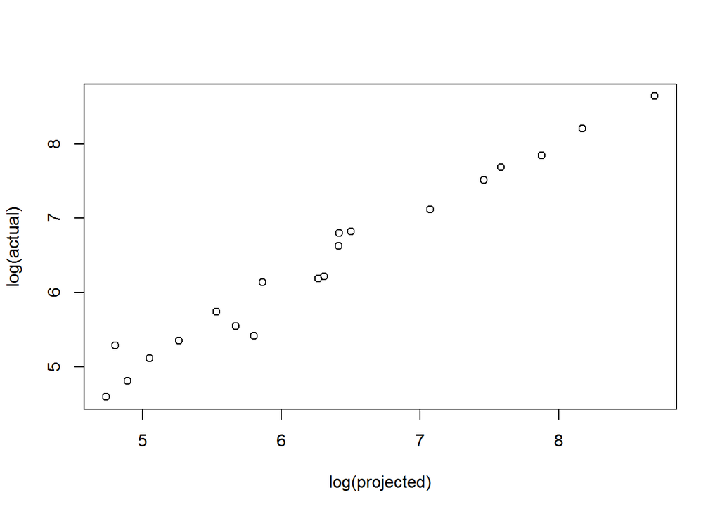

```r
with(cpd,plot(log(projected),log(actual)))
```

```r
loglmod<-lm(log(actual)~log(projected)-1,cpd)
summary(loglmod)
```

```
##
## Call:
## lm(formula = log(actual) ~ log(projected) - 1, data = cpd)
##
## Residuals:
##      Min       1Q   Median       3Q      Max
## -0.44158 -0.13406 -0.01902  0.15322  0.43824
##
## Coefficients:
##                Estimate Std. Error t value Pr(>|t|)
## log(projected)  1.00958    0.00719   140.4   <2e-16 ***
## ---
## Signif. codes:  0 '***' 0.001 '**' 0.01 '*' 0.05 '.' 0.1 ' ' 1
##
## Residual standard error: 0.2065 on 19 degrees of freedom
## Multiple R-squared:  0.999,  Adjusted R-squared:  0.999
## F-statistic: 1.971e+04 on 1 and 19 DF,  p-value: < 2.2e-16
```

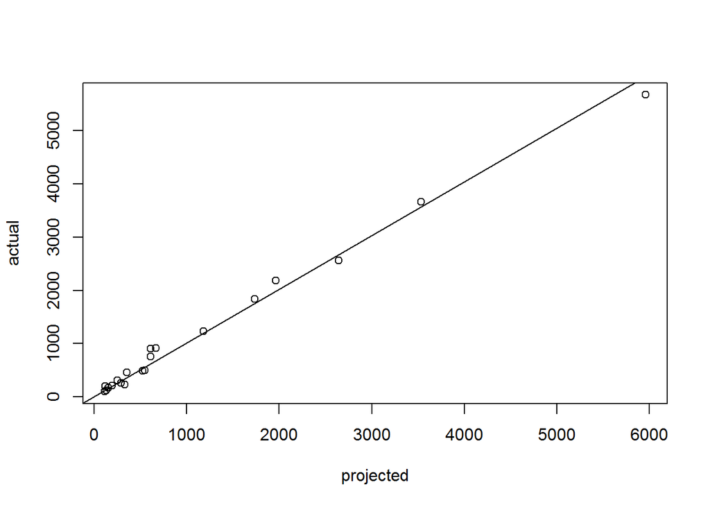

```r
plot(actual~projected,cpd)
abline(loglmod)
```

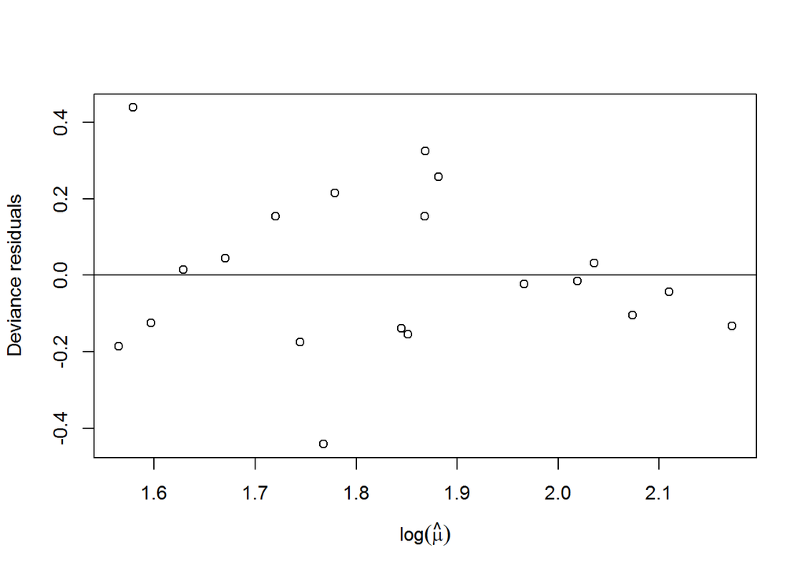

```r
plot(residuals(loglmod)~log(fitted(loglmod)),ylab="Deviance residuals",
     xlab=expression(log(hat(mu))))
abline(h=0)
```

```r
idx<-(loglmod$fitted.values<median(loglmod$fitted.values))
bptest(log(cpd$actual)~log(cpd$projected))
```

```
##
##  studentized Breusch-Pagan test
##
## data:  log(cpd$actual) ~ log(cpd$projected)
## BP = 2.8028, df = 1, p-value = 0.0941
```

```r
fligner.test(loglmod$residuals,idx)
```

```
##
##  Fligner-Killeen test of homogeneity of variances
##
## data:  loglmod$residuals and idx
## Fligner-Killeen:med chi-squared = 1.2618, df = 1, p-value = 0.2613
```

This may have helped solving the problem.

Fit inverse Gaussian model.

```r
igmod<-glm(actual~projected-1,family=inverse.gaussian(link="identity"),data=cpd)
summary(igmod)
```

```
##
## Call:
## glm(formula = actual ~ projected - 1, family = inverse.gaussian(link = "identity"),
##     data = cpd)
##
## Deviance Residuals:
##       Min         1Q     Median         3Q        Max
## -0.025603  -0.007481  -0.001257   0.004970   0.033446
##
## Coefficients:
##           Estimate Std. Error t value Pr(>|t|)
## projected  1.10358    0.06143   17.96 2.22e-13 ***
## ---
## Signif. codes:  0 '***' 0.001 '**' 0.01 '*' 0.05 '.' 0.1 ' ' 1
##
## (Dispersion parameter for inverse.gaussian family taken to be 0.0001701237)
##
##     Null deviance:       Inf  on 20  degrees of freedom
## Residual deviance: 0.0030616  on 19  degrees of freedom
## AIC: 268.13
##
## Number of Fisher Scoring iterations: 3
```

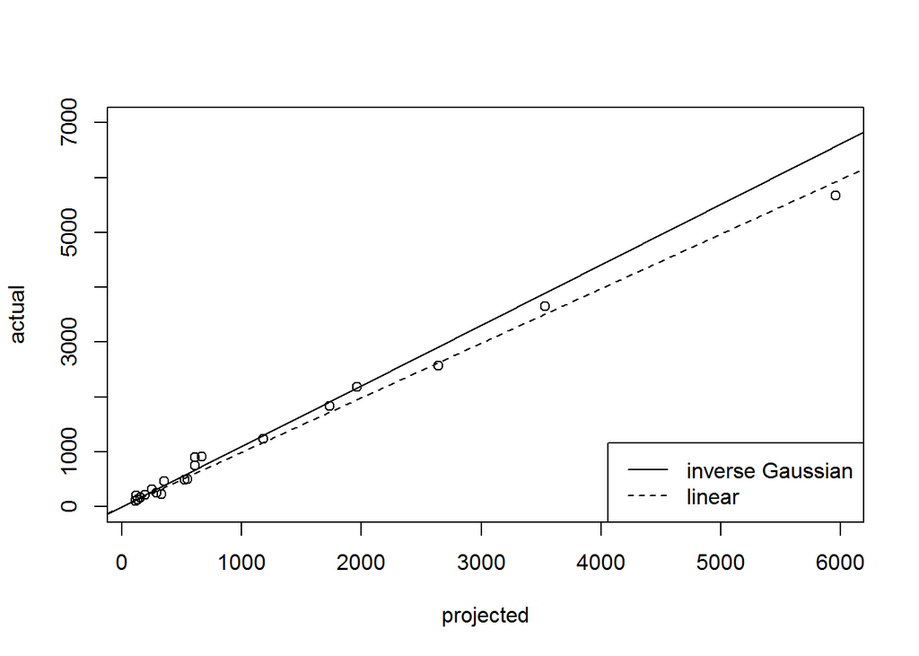

```r
plot(actual~projected,cpd,ylim=c(0,7000))
abline(igmod,lty=1)
abline(lmod,lty=2)
legend("bottomright",legend=c("inverse Gaussian","linear"),lty=1:2,col="black")
```

There is significant difference in slope estimates between `lmod` and `igmod`.

Plot deviance residuals against fitted values stretched by log-transformation in order to distribute them more evenly.

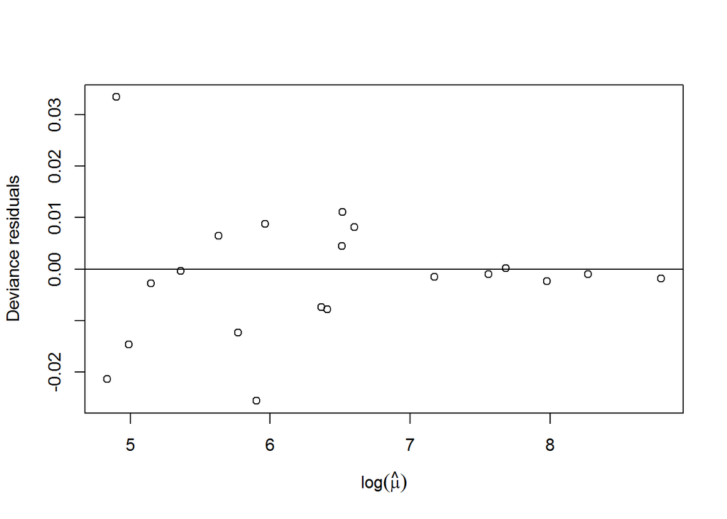

```r
plot(residuals(igmod)~log(fitted(igmod)),ylab="Deviance residuals",
     xlab=expression(log(hat(mu))))
abline(h=0)
```

The graph shows that variance explained by this model still decreases with mean value.

```r
idx<-(igmod$fitted.values<median(igmod$fitted.values))
fligner.test(igmod$residuals,idx)
```

```
##
##  Fligner-Killeen test of homogeneity of variances
##
## data:  igmod$residuals and idx
## Fligner-Killeen:med chi-squared = 3.8303, df = 1, p-value =
## 0.05033
```

Fit gamma model to the same data and compare the fits.  
Select appropriate link.

(Skipped Code)

Compare the fits and residuals.

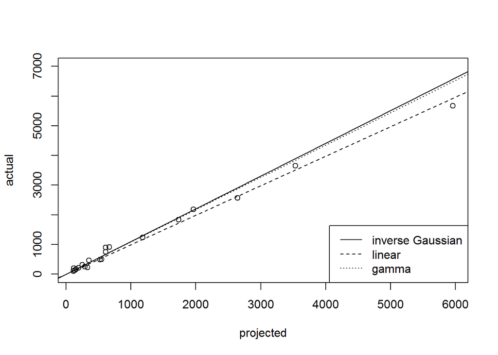

```r
plot(actual~projected,cpd,ylim=c(0,7000))
abline(igmod,lty=1)
abline(lmod,lty=2)
abline(gamod,lty=3)
legend("bottomright",legend=c("inverse Gaussian","linear","gamma"),lty=1:3,col="black")
```

Gamma regression returns similar results to inverse Gaussian model.

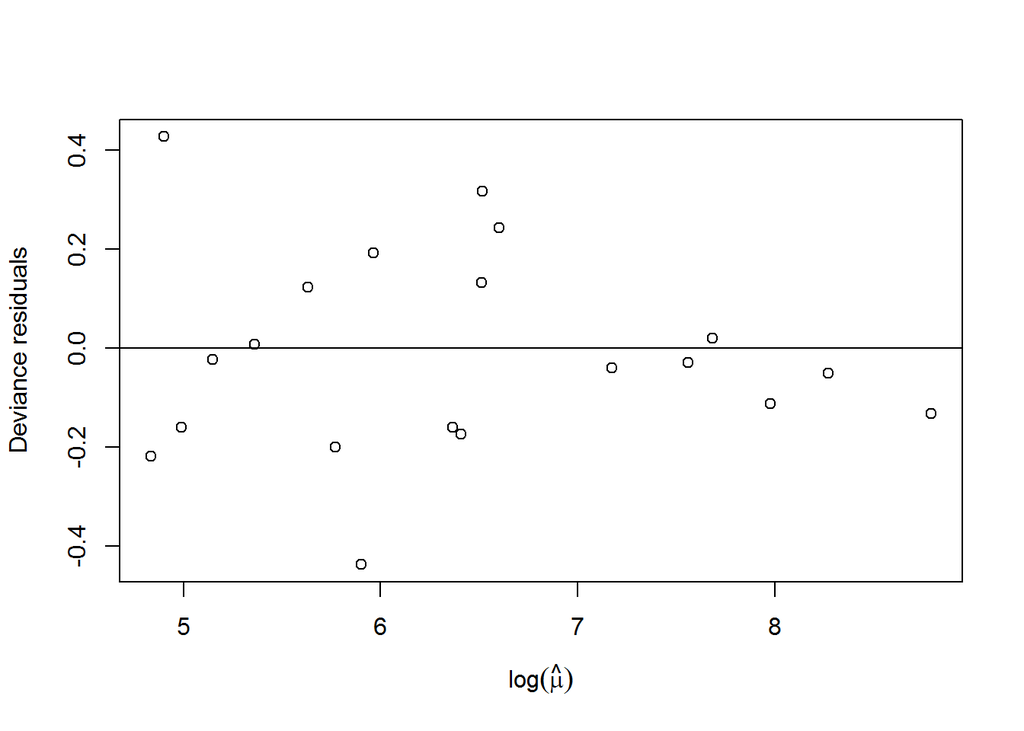

```r
plot(residuals(gamod)~log(fitted(igmod)),ylab="Deviance residuals",xlab=expression(log(hat(mu))))
abline(h=0)
```

```r
idx<-(gamod$fitted.values<median(gamod$fitted.values))
fligner.test(gamod$residuals,idx)
```

```
##
##  Fligner-Killeen test of homogeneity of variances
##
## data:  gamod$residuals and idx
## Fligner-Killeen:med chi-squared = 4.1091, df = 1, p-value =
## 0.04265
```

Fligner test rejects homoskedasticity, but not by much.

Compare all residuals.

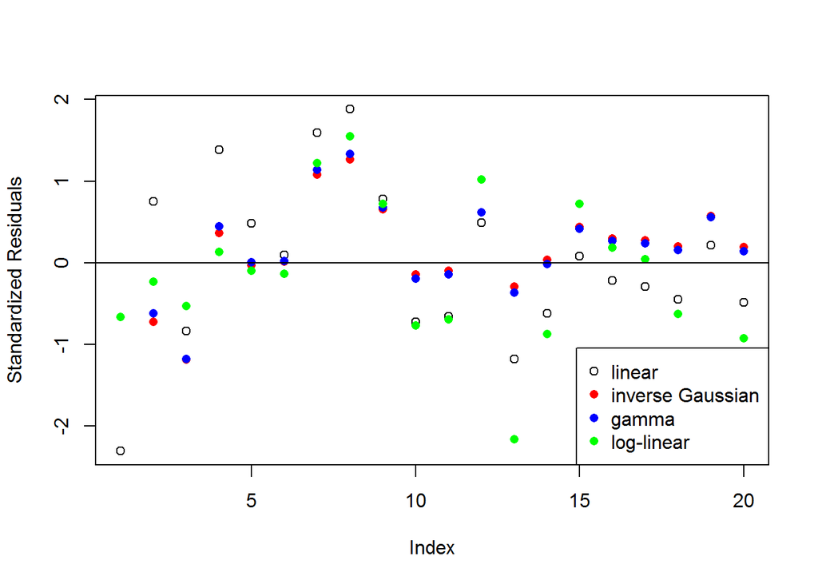

```r
plot((lmod$res-mean(lmod$res))/sd(lmod$res),type="p",ylab="Standardized Residuals",
     pch=1,col="black")
points((igmod$res-mean(igmod$res))/sd(igmod$res),pch=16,col="red")
points((gamod$res-mean(gamod$res))/sd(gamod$res),pch=16,col="blue")
points((loglmod$res-mean(loglmod$res))/sd(loglmod$res),pch=16,col="green")
abline(h=0)
legend("bottomright",legend=c("linear","inverse Gaussian",
                              "gamma","log-linear"),pch=c(1,16,16,16),
       col=c("black","red","blue","green"))
```

Even though residuals of all models are not homoskedastic inverse Gaussian and gamma models seem to explain the data better.

# 5 Poison treatment example

This example looks at effect of treatments after poisoning by certain toxic agents.  
The data for rat poisoning and treatment experiment can be found as data set `poisons` in `boot`.

```r
suppressWarnings(library(boot))
suppressWarnings(attach(poisons))
```

```r
poisons
```

```
##    time poison treat
## 1  0.31      1     A
## 2  0.45      1     A
## 3  0.46      1     A
## 4  0.43      1     A
## 5  0.36      2     A
## 6  0.29      2     A
## 7  0.40      2     A
## 8  0.23      2     A
## 9  0.22      3     A
## 10 0.21      3     A
## 11 0.18      3     A
## 12 0.23      3     A
## 13 0.82      1     B
## 14 1.10      1     B
```

[output cut: 34 more lines]

Look at the data with simple box plots and then interaction plots:

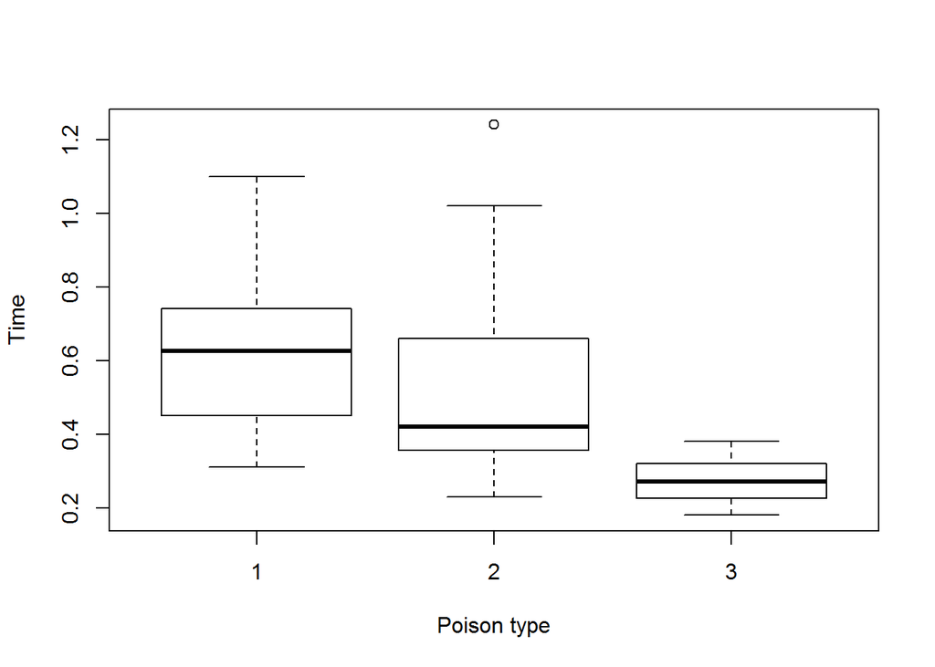

```r
with(poisons,boxplot(time~poison,xlab="Poison type",ylab="Time"))
```

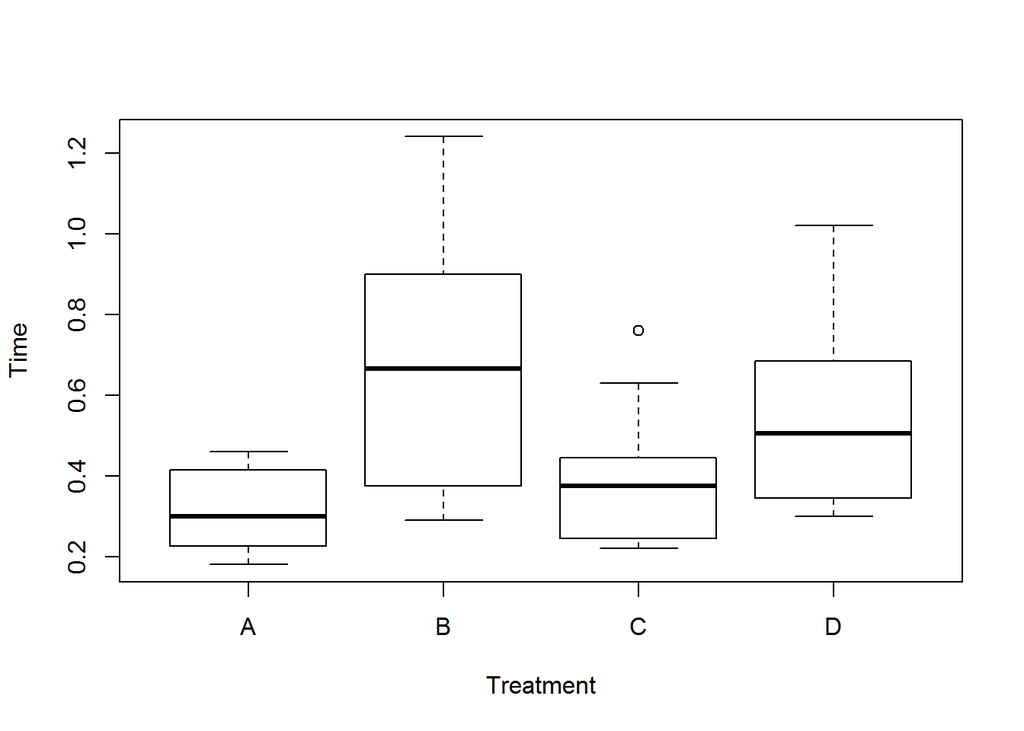

```r
with(poisons,boxplot(time~treat,xlab="Treatment",ylab="Time"))
```

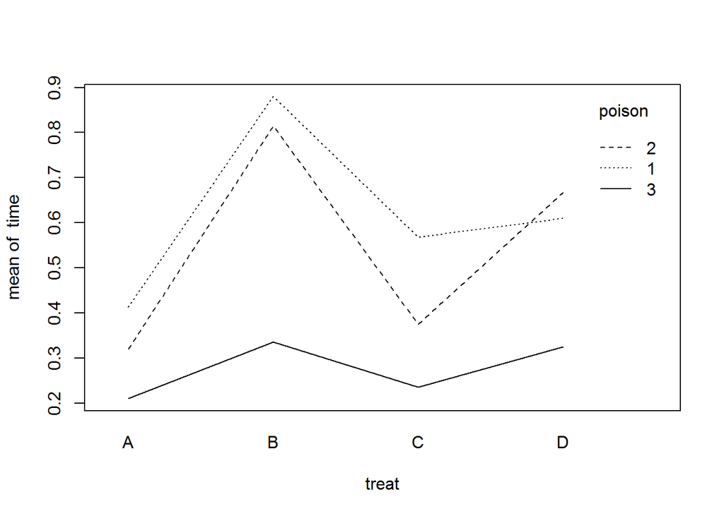

```r
with(poisons,interaction.plot(treat,poison,time))
```